# Multivariate Data

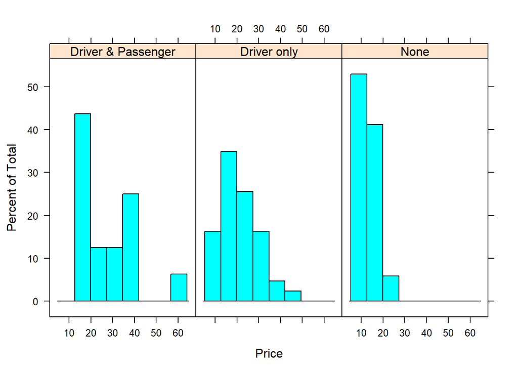

```r
> histogram( ~ Price | AirBags, data = Cars93)
```

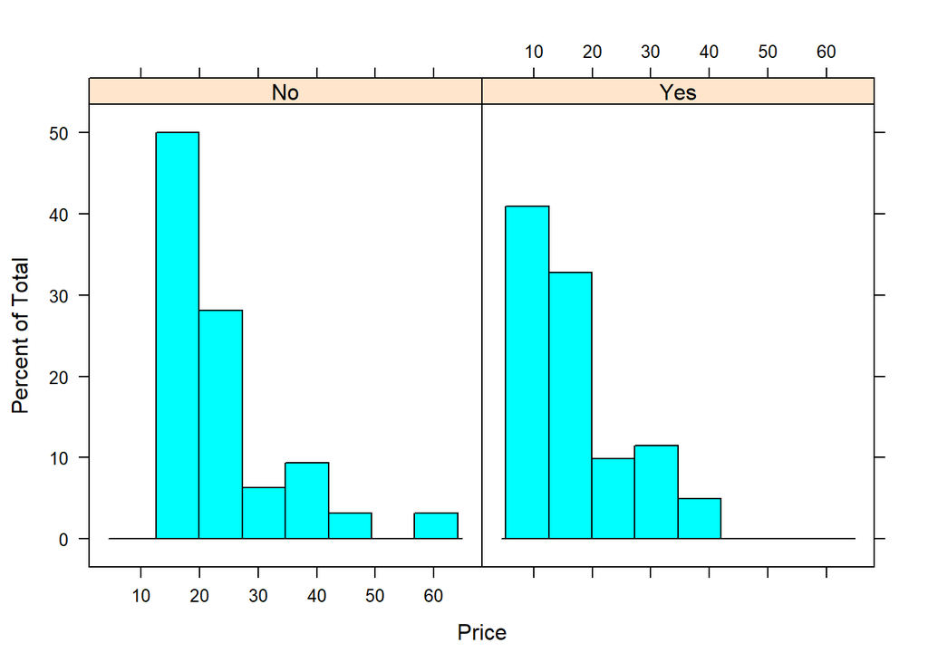

```r
> histogram( ~ Price | Man.trans.avail, data = Cars93)
```

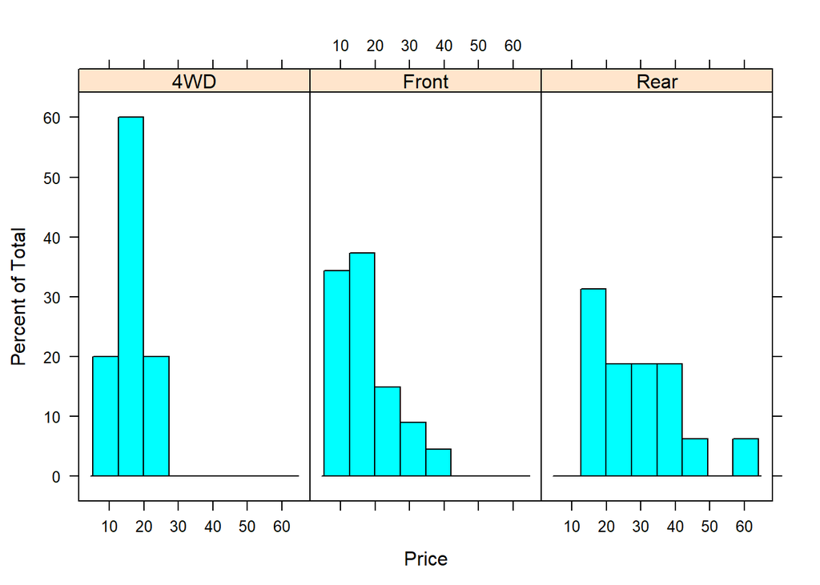

```r
> histogram( ~ Price | DriveTrain, data = Cars93)
```

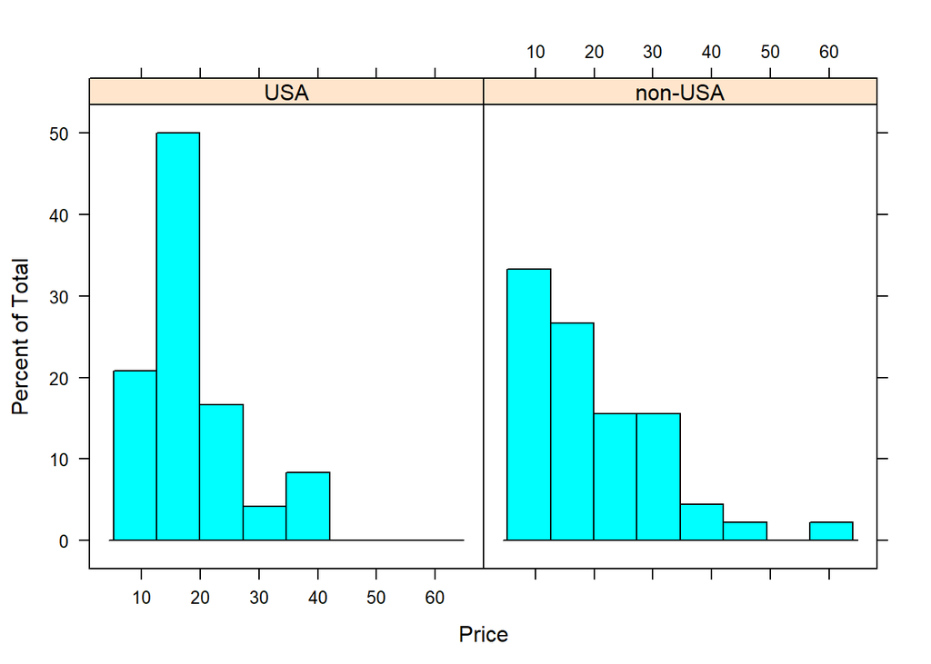

```r
> histogram( ~ Price | Origin, data = Cars93)
```

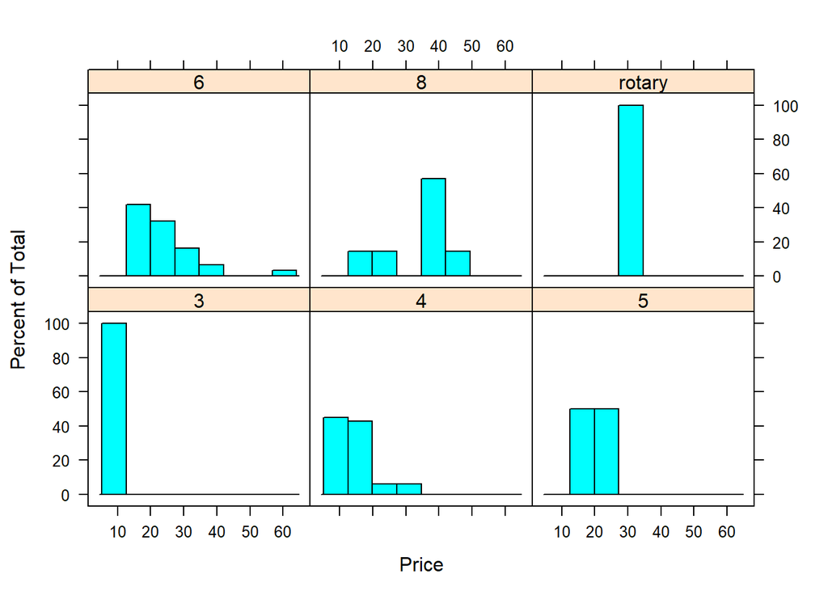

```r
> histogram( ~ Price | Cylinders , data = Cars93)
```

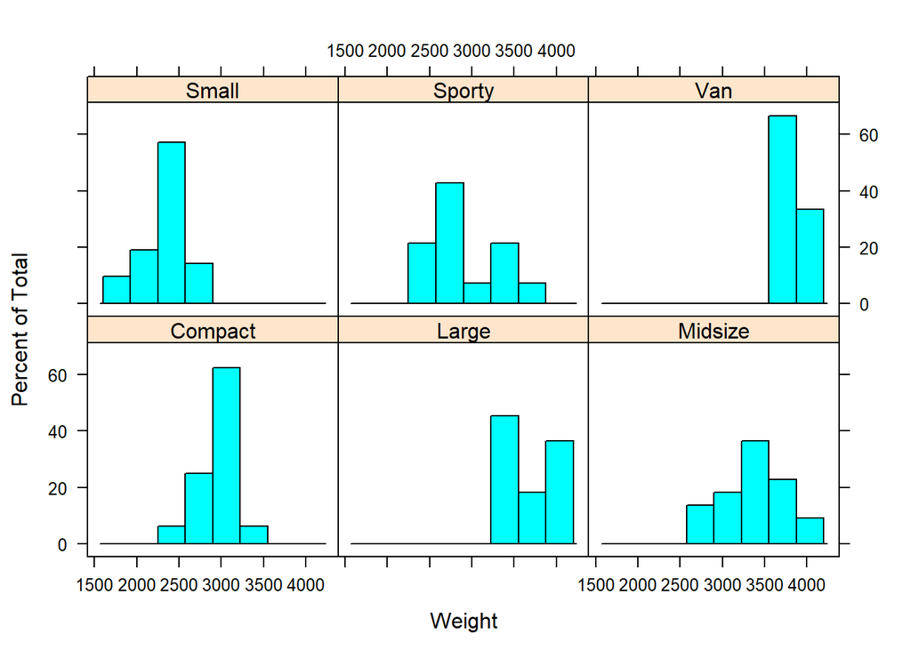

```r
> histogram( ~ Weight | Type , data = Cars93)
```

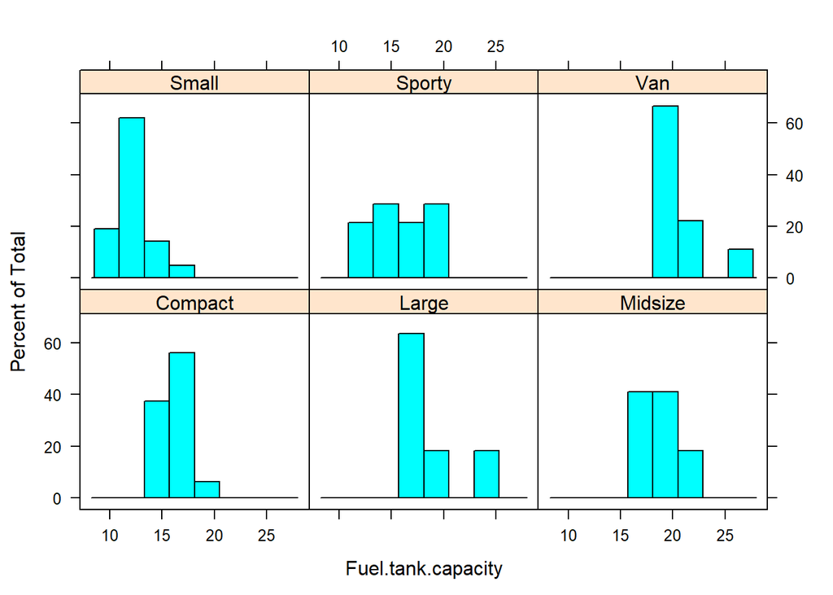

```r
> histogram( ~ Fuel.tank.capacity | Type , data = Cars93)
```

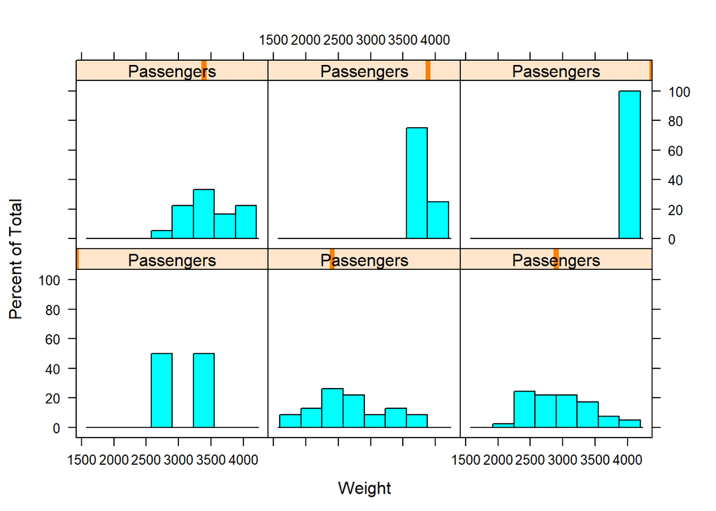

```r
> histogram( ~ Weight | Passengers , data = Cars93)
```

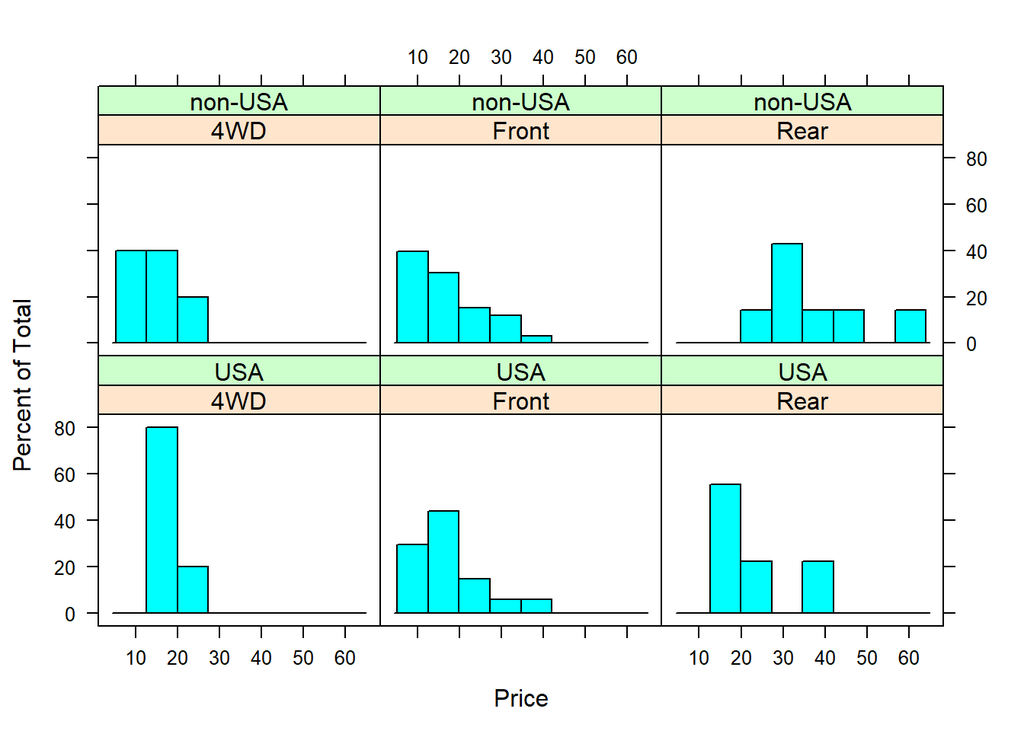

```r
> histogram( ~ Price | DriveTrain * Origin, data = Cars93)
```

We can similarly make the boxplot (box-and-whisker plots) lattice graphics using the `bwplot` function

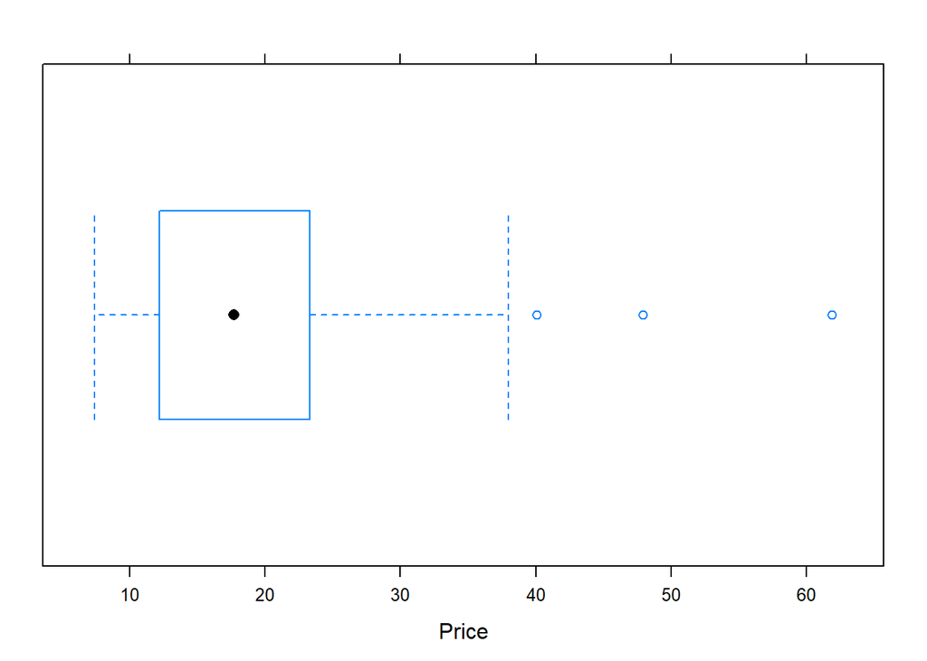

```r
> bwplot( ~ Price, data = Cars93)
```

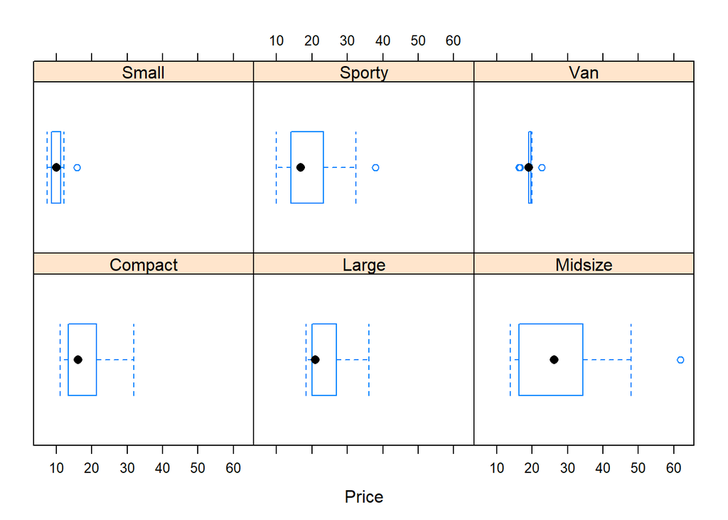

```r
> bwplot( ~ Price | Type, data = Cars93)
```

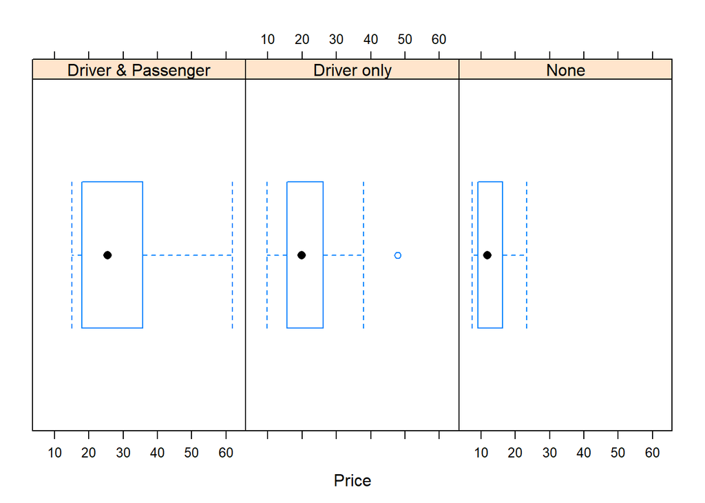

```r
> bwplot( ~ Price | AirBags, data = Cars93)
```

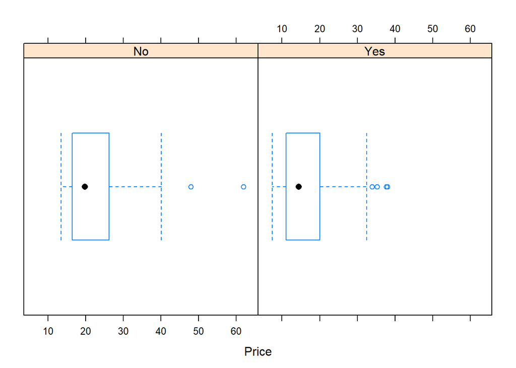

```r
> bwplot( ~ Price | Man.trans.avail, data = Cars93)
```

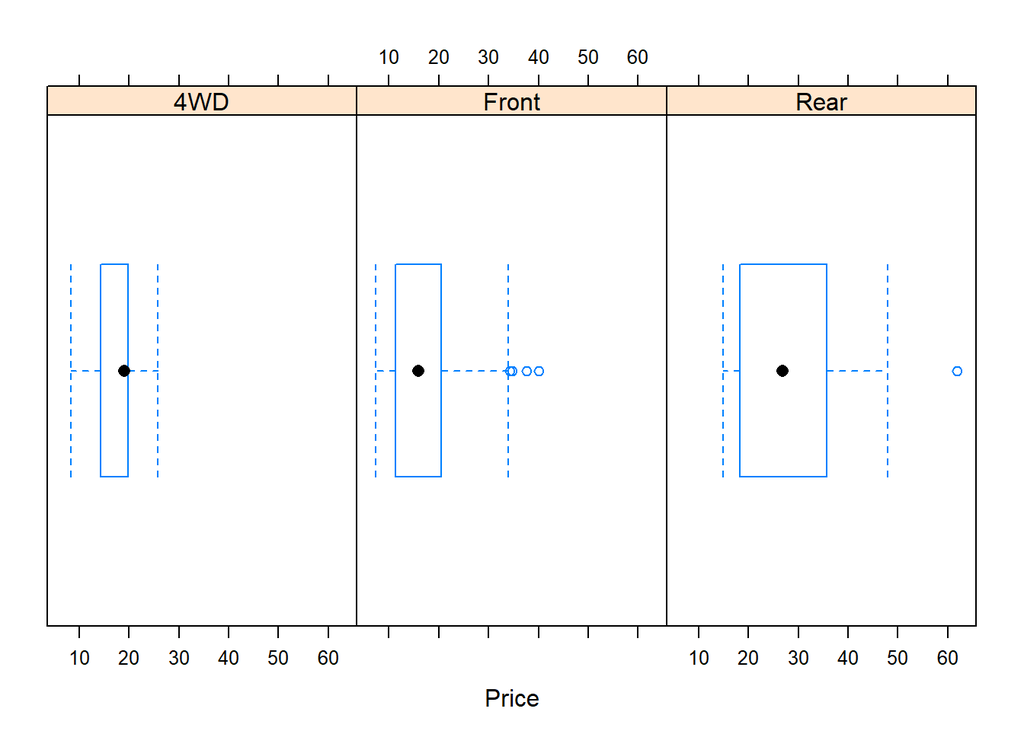

```r
> bwplot( ~ Price | DriveTrain, data = Cars93)
```

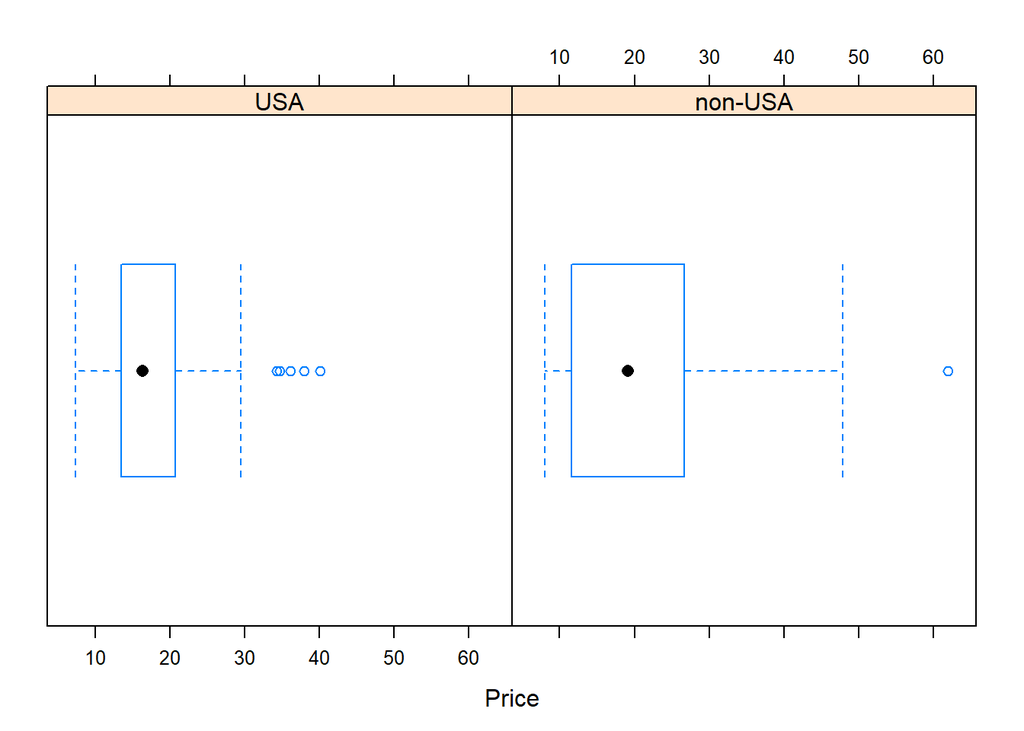

```r
> bwplot( ~ Price | Origin, data = Cars93)
```

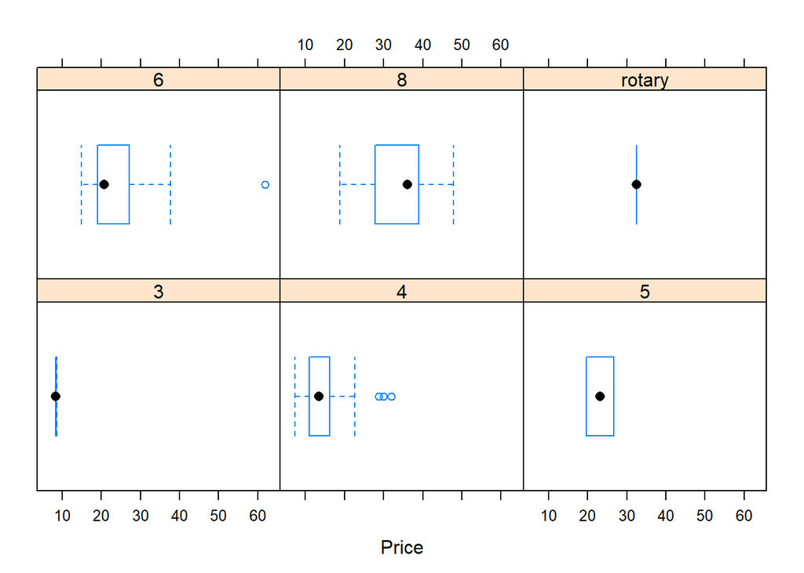

```r
> bwplot( ~ Price | Cylinders , data = Cars93)
```

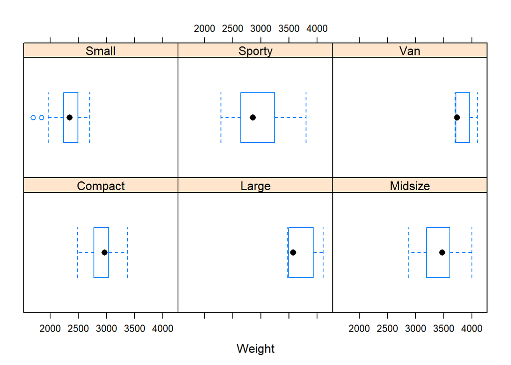

```r
> bwplot( ~ Weight | Type , data = Cars93)
```

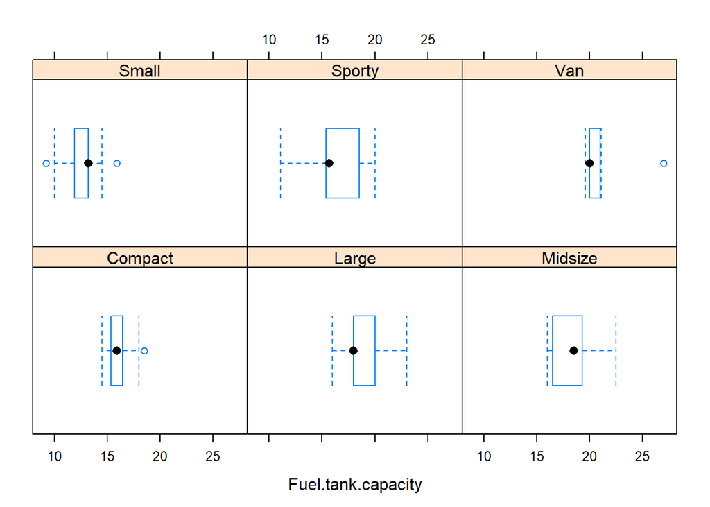

```r
> bwplot( ~ Fuel.tank.capacity | Type , data = Cars93)
```

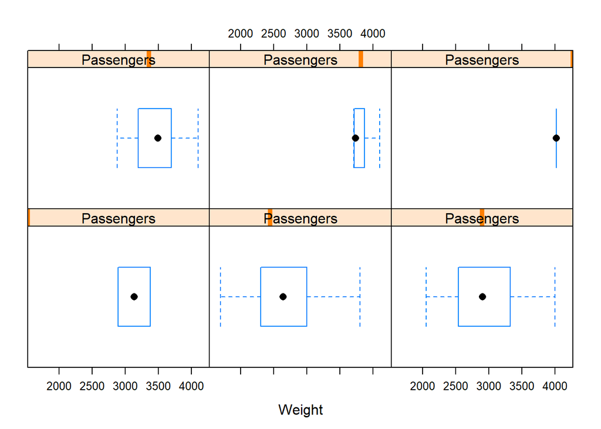

```r
> bwplot( ~ Weight | Passengers , data = Cars93)
```

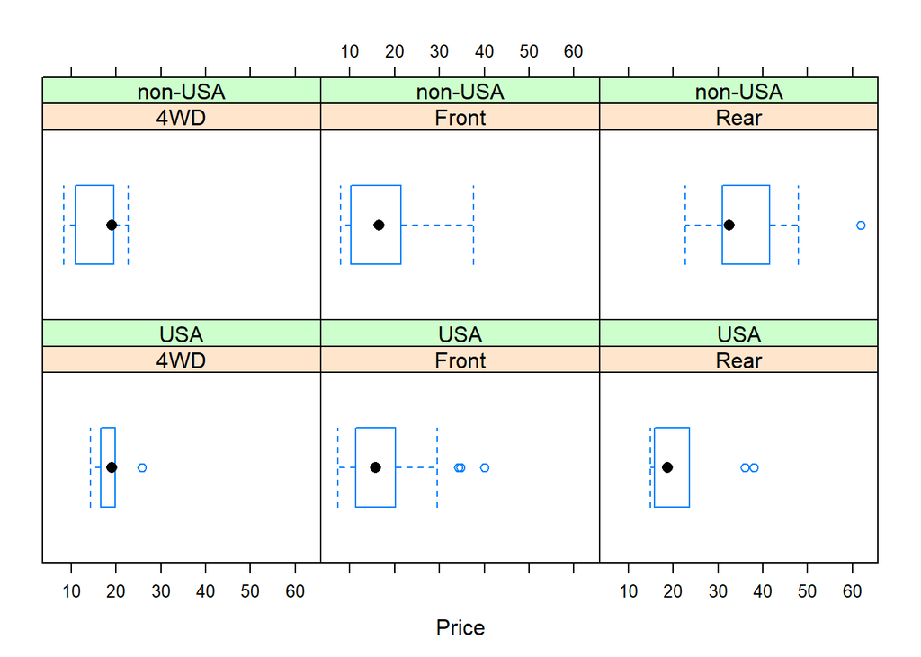

```r
> bwplot( ~ Price | DriveTrain * Origin, data = Cars93)
```

### Numerical data

For the next example let’s review the `emissions` data set containing gross domestic product (GDP), gross domestic product (GDP) per capita and CO2 emissions estimated for 26 countries in 1999.

```r
> head(emissions)
                  GDP perCapita  CO2
UnitedStates  8083000     29647 6750
Japan         3080000     24409 1320
Germany       1740000     21197 1740
France        1320000     22381  550
UnitedKingdom 1242000     21010  675
Italy         1240000     21856  540
```

Is there a relationship between the gross domestic product and the CO2 emissions?

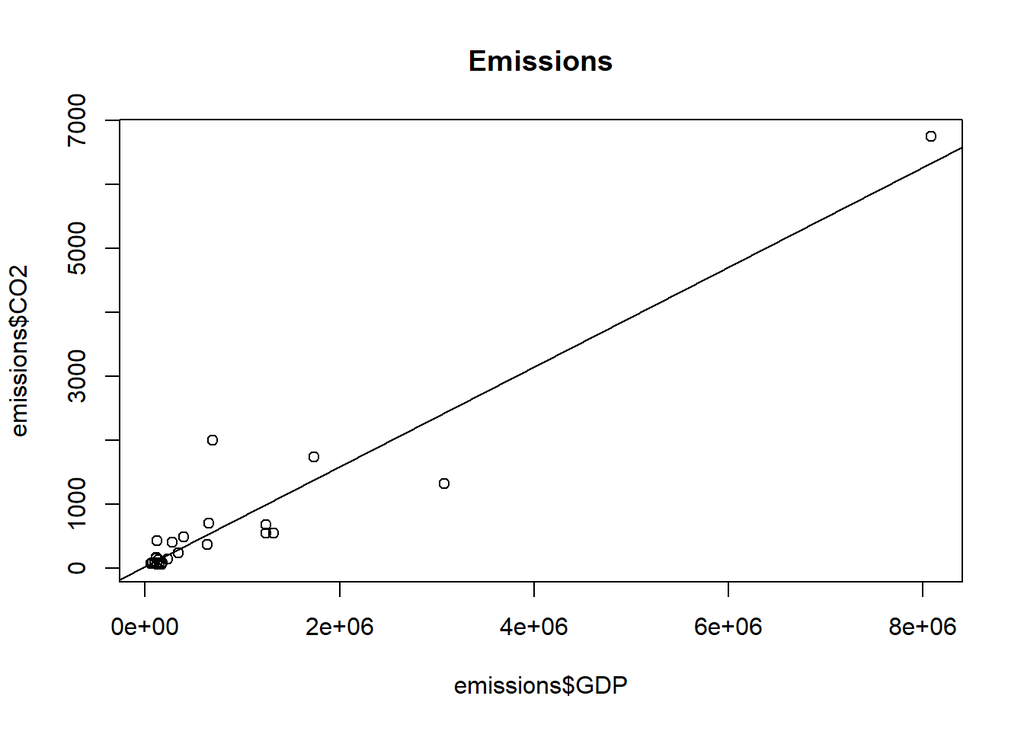

```r
> cor(emissions$GDP, emissions$CO2)
[1] 0.95
> plot(emissions$CO2 ~ emissions$GDP, main = "Emissions")
> abline(lm(emissions$CO2 ~ emissions$GDP))
```

Another way was using `simple.lm` function from the `UsingR` package

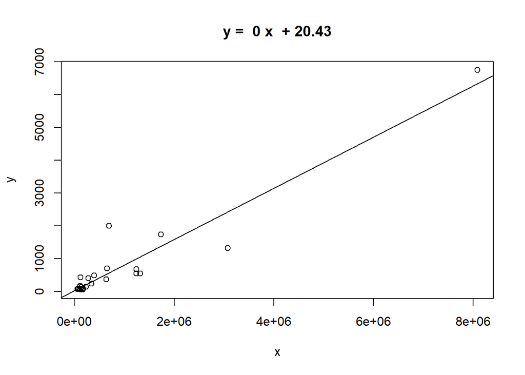

```
Call:
lm(formula = y ~ x)

Coefficients:
(Intercept)            x
   2.04e+01     7.81e-04
```

```r
> simple.lm(emissions$GDP, emissions$CO2)
```

We can also see the distributions and the relation ship at the same time, we can use `simple.scatterplot` function.

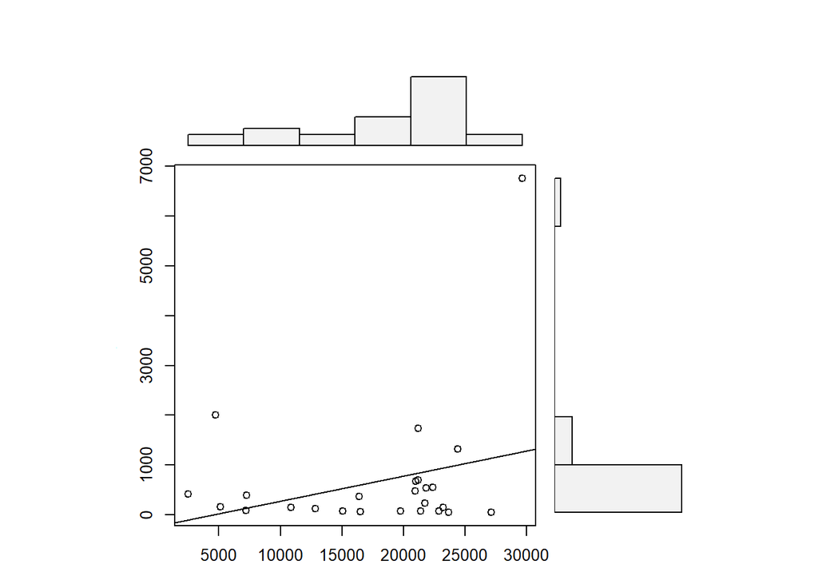

```r
> simple.scatterplot(emissions$perCapita, emissions$CO2)
```

And we see that we can make plots for all the variables in the data frame simultaneously using the `pairs` function, there are a lot customize attributes for this function

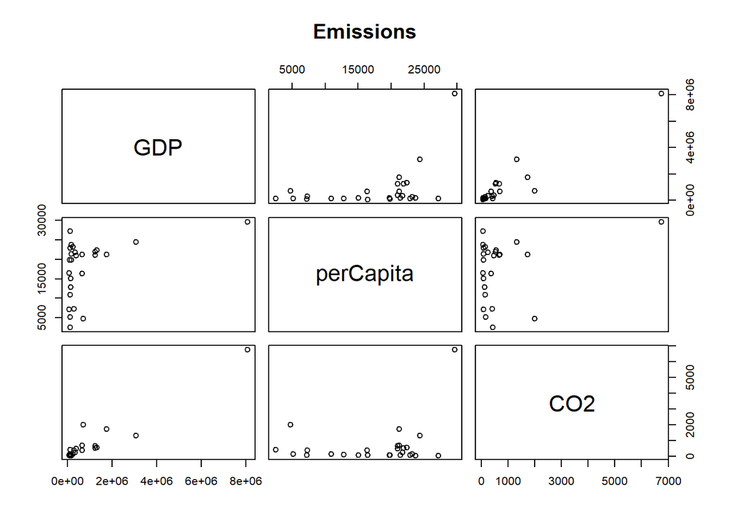

```r
> pairs(emissions, main = "Emissions")
```

For example using this syntax we can chose which variables to include in the model and how to order them. Also as we already saw by using `col` and `pch` we can change the color and the symbol of data representation.

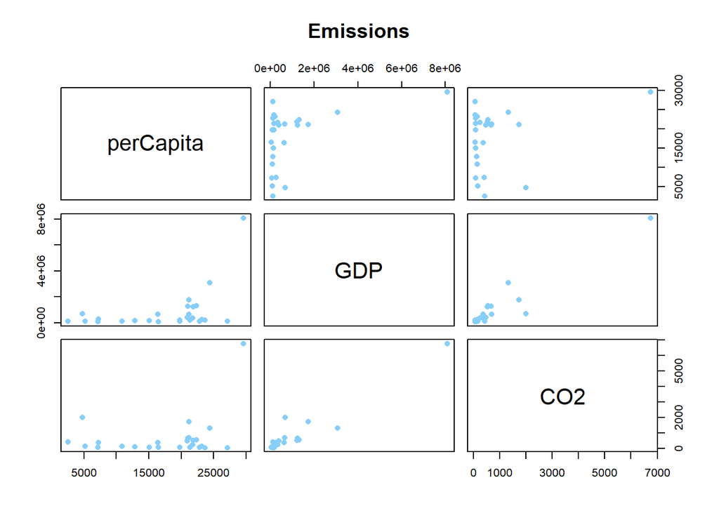

```r
> pairs( ~ perCapita + GDP + CO2, data = emissions,
+       main = "Emissions",
+       col = "lightskyblue",
+       pch = 16)
```

For the next example we are going to review `environmental` data frame from `lattice` package showing daily measurements of average ozone concentration (of hourly measurements) in parts per billion, solar radiation (from 08:00 to 12:00) in langleys, maximum temperature in Fahrenheit and average wind speed (at 07:00 and 10:00) in miles per hour in New York City from May to September of 1973.

```r
> head(environmental)
  ozone radiation temperature wind
1    41       190          67  7.4
2    36       118          72  8.0
3    12       149          74 12.6
4    18       313          62 11.5
5    23       299          65  8.6
6    19        99          59 13.8
```

By using the base plotting system we can plot the data for ozone and radiation as above

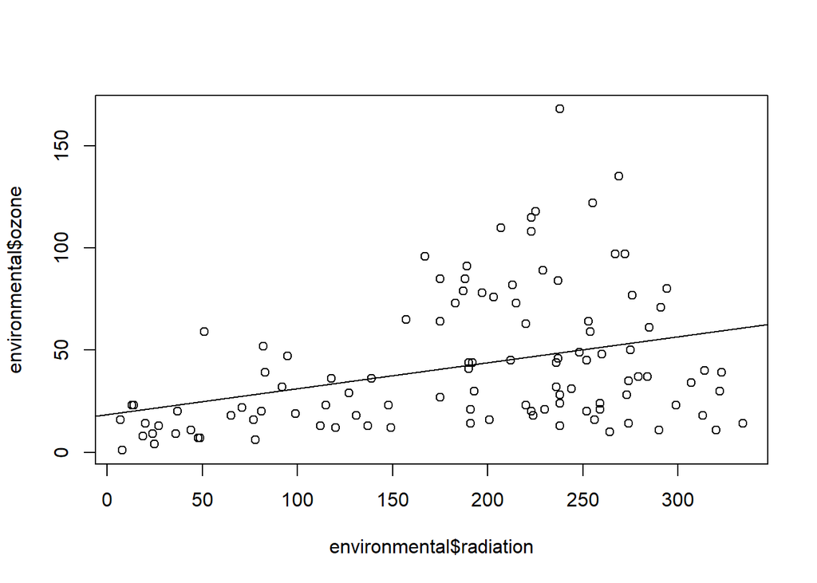

```r
> cor(environmental$radiation, environmental$ozone)
[1] 0.35
> plot(environmental$ozone ~ environmental$radiation)
> abline(lm(environmental$ozone ~ environmental$radiation))
```

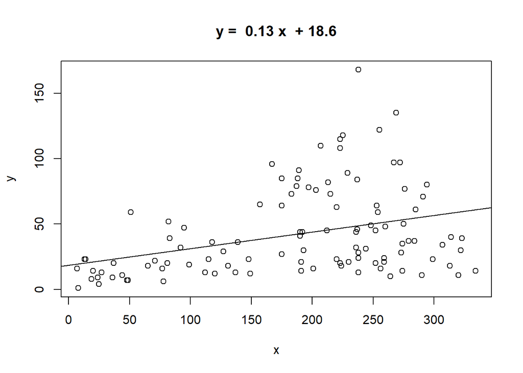

```
Call:
lm(formula = y ~ x)

Coefficients:
(Intercept)            x
     18.599        0.127
```

```r
> simple.lm(environmental$radiation, environmental$ozone)
```

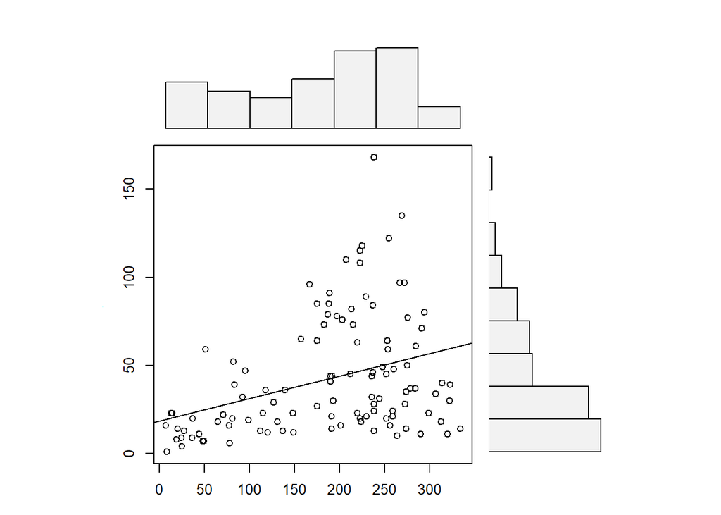

```r
> simple.scatterplot(environmental$radiation, environmental$ozone)
```

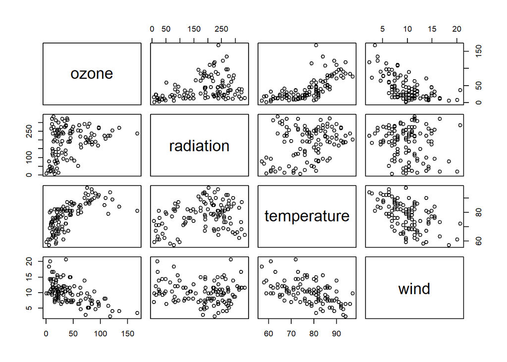

```r
> pairs(environmental)
```

We can use `xyplot` from `lattice` package to make the scatterplot of ozone and radiation. We use the same syntax as above `response ~ predictor`

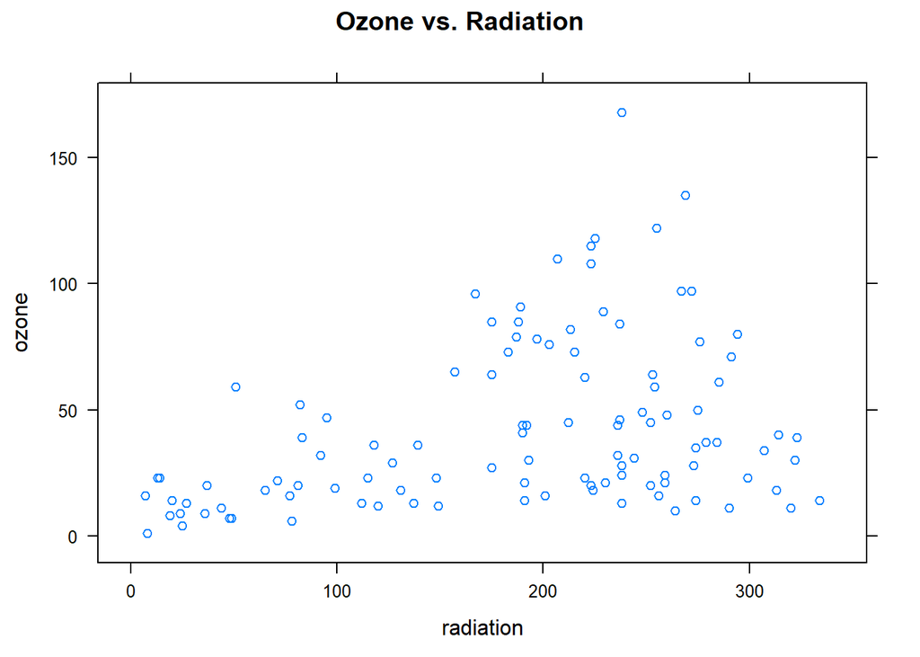

```r
> xyplot(ozone ~ radiation, data = environmental,
+        main = "Ozone vs. Radiation")
```

Also we can see the relation between ozone and temperature

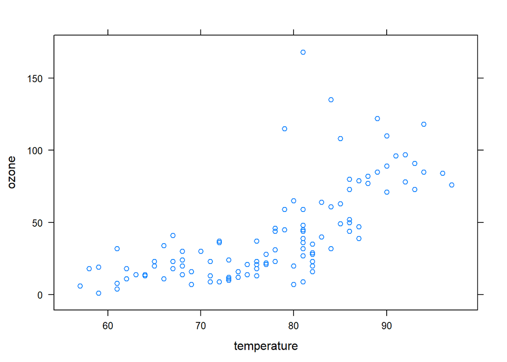

```r
> xyplot(ozone ~ temperature, data = environmental)
```

We can also use `qplot` from `ggplot` package to make the scatterplot of ozone and radiation.

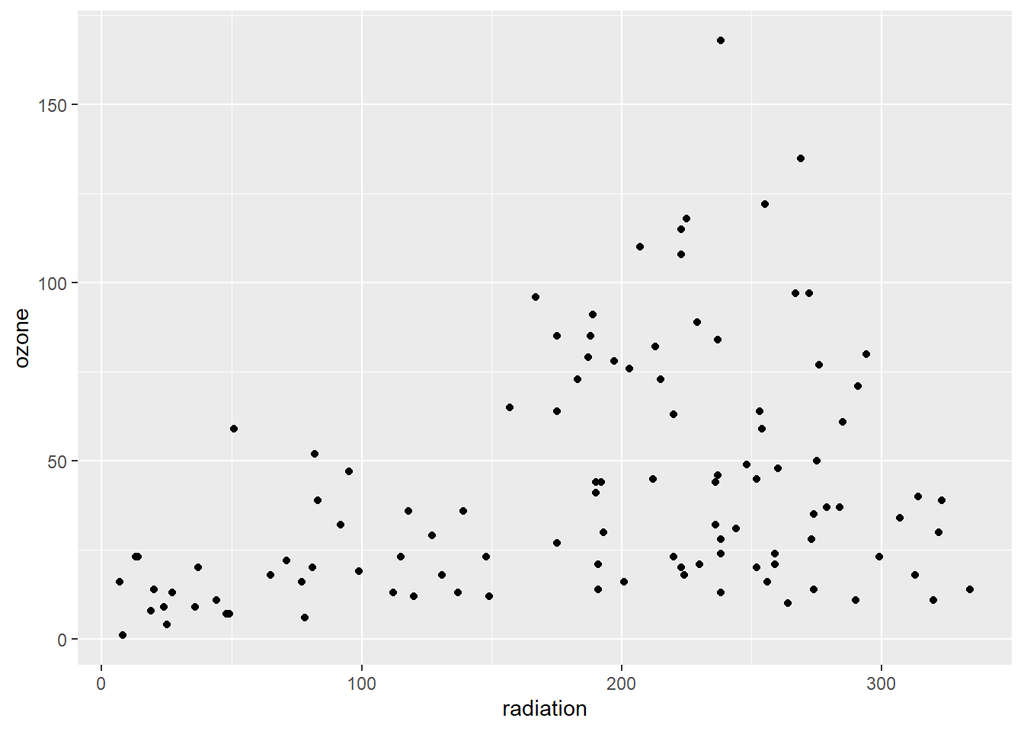

```r
> qplot(radiation, ozone, data = environmental)
```

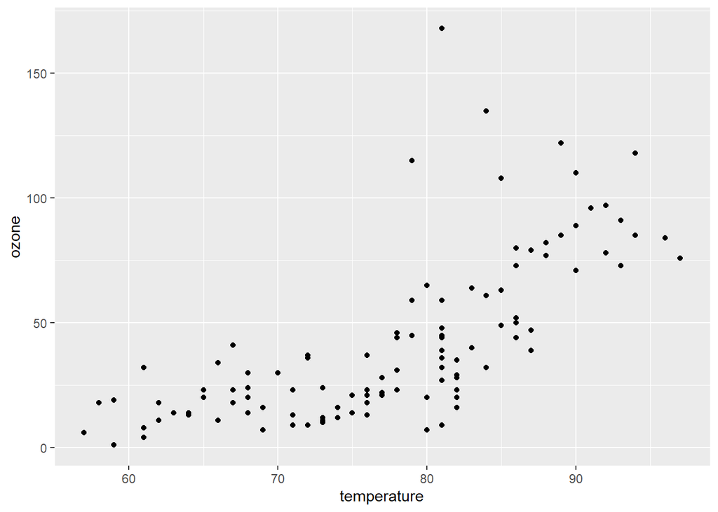

```r
> qplot(temperature, ozone, data = environmental)
```

Does the relationship between ozone and radiation change as the temperature changes? We can cut the temperature interval in 3 subsets

```r
> summary(environmental$temperature)
   Min. 1st Qu.  Median    Mean 3rd Qu.    Max.
     57      71      79      78      84      97
> temperature.cut <- cut(environmental$temperature, 3)
```

Continuing with `lattice` package we can make a scatterplot for every subset of temperature intervals

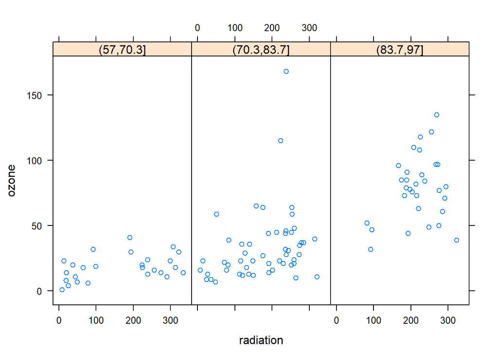

```r
> xyplot(ozone ~ radiation | temperature.cut, data = environmental)
```

We can tune it up if we want. We can order the graphics in one column for example.

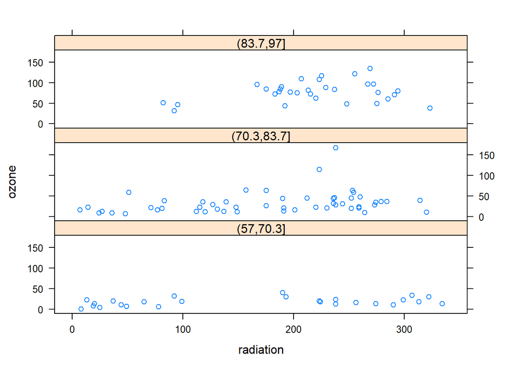

```r
> xyplot(ozone ~ radiation | temperature.cut, data = environmental, layout = c(1, 3))
```

We can also add additional function to the panels. In this example we calculate a linear model and add a linear regression line to the panels.

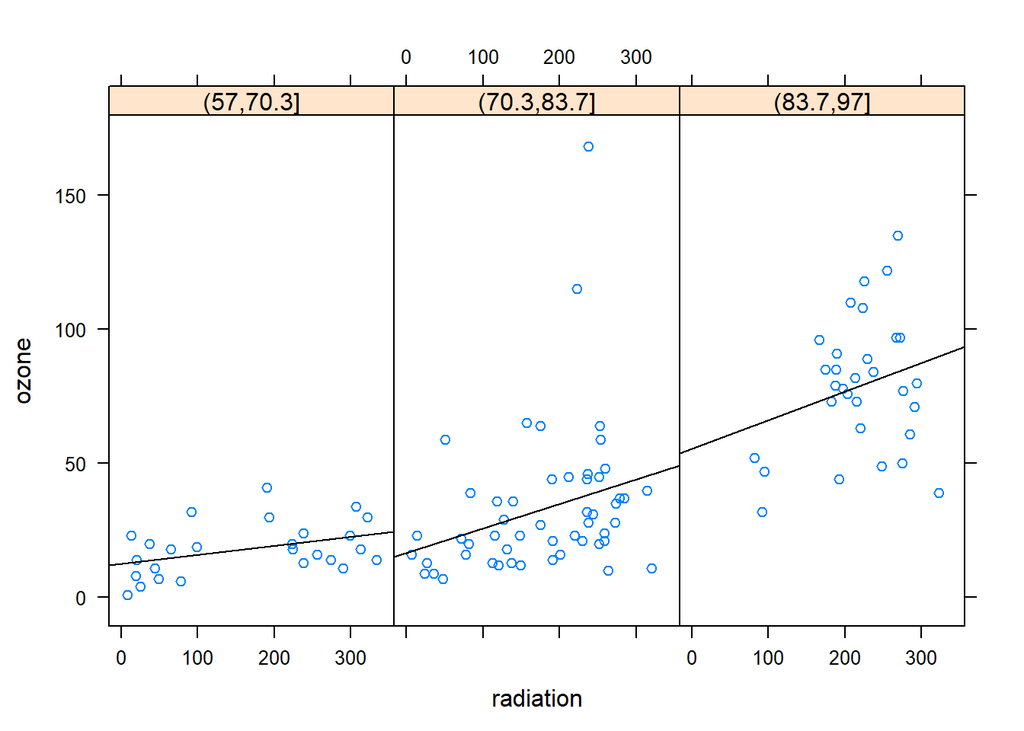

```r
> xyplot(ozone ~ radiation | temperature.cut, data = environmental,
+        panel = function(x, y, ...){
+          panel.xyplot(x, y, ...)
+          fit <- lm(y ~ x)
+          panel.abline(fit)
+        })
```

We can also change graphic’s labels, colors and symbols.

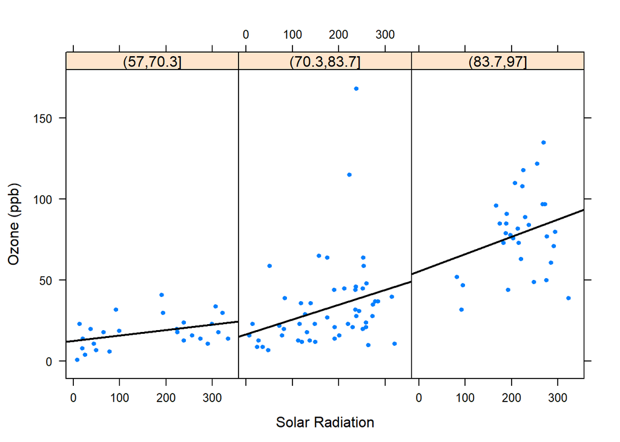

```r
> xyplot(ozone ~ radiation | temperature.cut, data = environmental,
+        panel = function(x, y, ...){
+          panel.xyplot(x, y, ...)
+          fit <- lm(y ~ x)
+          panel.abline(fit, lwd = 2)
+        },
+        xlab = "Solar Radiation",
+        ylab = "Ozone (ppb)",
+        pch = 20)
```

Let’s see how ozone and solar radiation change when both temperature and wind change?

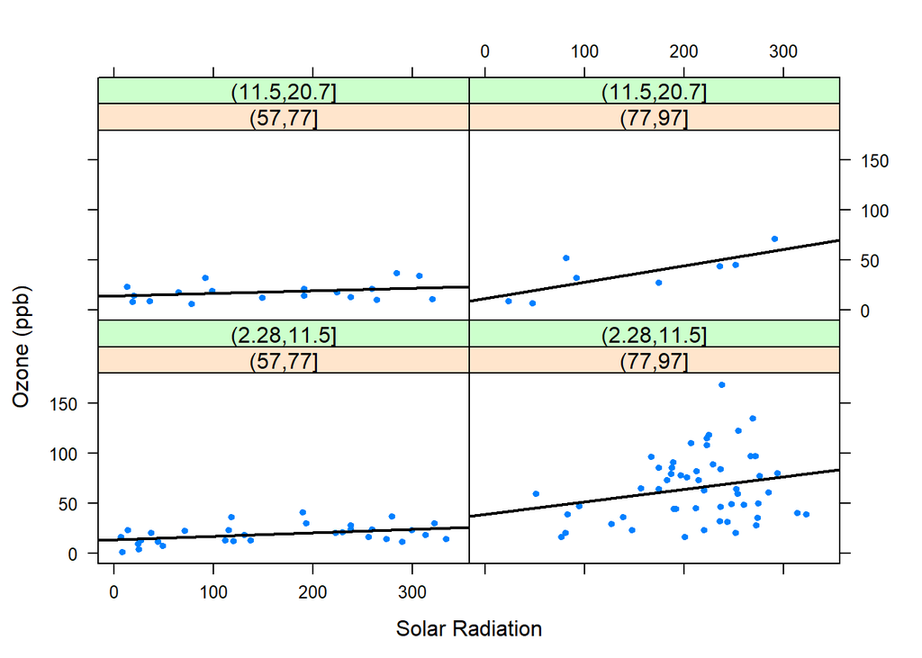

```r
> temperature.cut <- cut(environmental$temperature, 2)
> wind.cut <- cut(environmental$wind, 2)
> xyplot(ozone ~ radiation | temperature.cut * wind.cut, data = environmental,
+        panel = function(x, y, ...){
+          panel.xyplot(x, y, ...)
+          fit <- lm(y ~ x)
+          panel.abline(fit, lwd = 2)
+        },
+        xlab = "Solar Radiation",
+        ylab = "Ozone (ppb)",
+        pch = 20)
```

As you see `xyplot` function is useful of making this kind of conditioning plots where we plot the relationship between two variables by conditioning on the values of third variable.

`splom` form `lattice` is similar to `pairs` function base graphics package

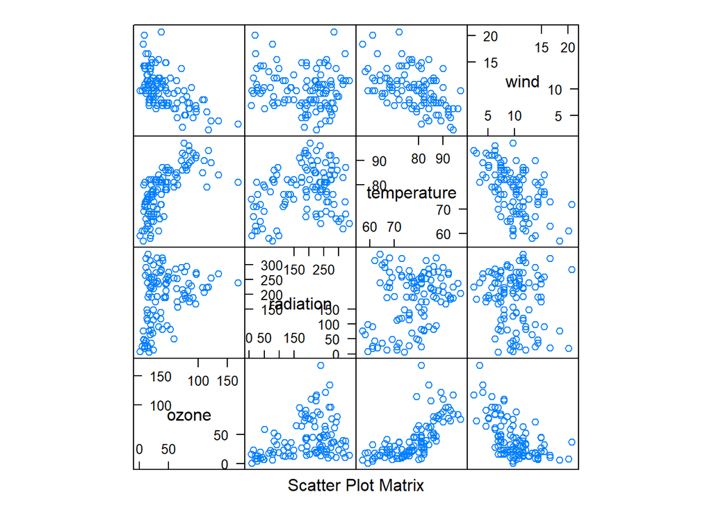

```r
> splom( ~ environmental)
```

Another example again with `Cars93` data frame for `MPG.highway` and `Fuel.tank.capacity`

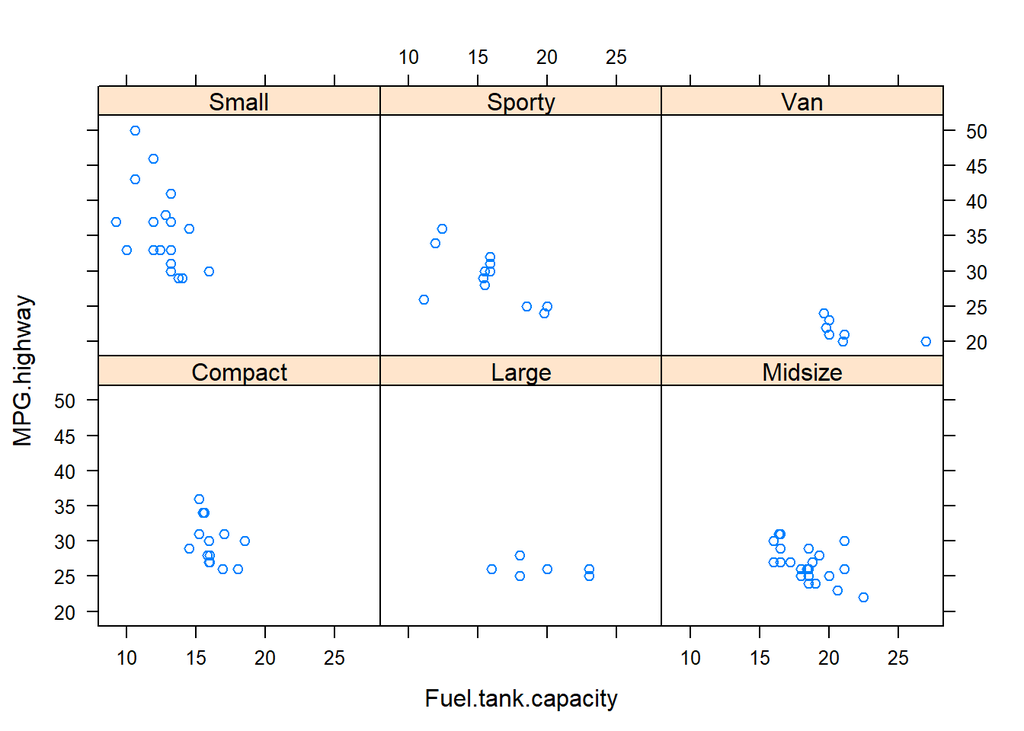

```r
> xyplot(MPG.highway ~ Fuel.tank.capacity | Type, data = Cars93)
```

Let’s also add the linear regression lines

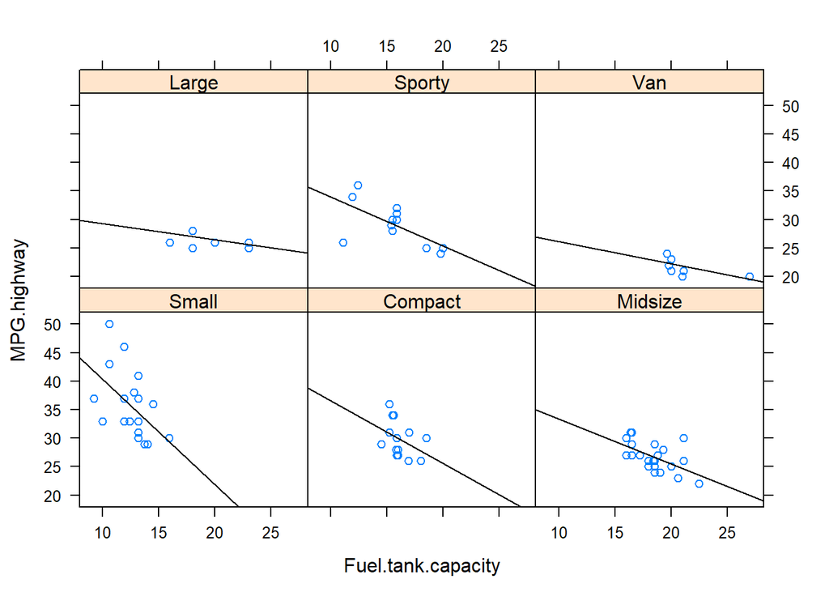

```r
> plot.regression = function(x,y) {
+   panel.xyplot(x,y)
+   panel.abline(lm(y~x))
+ }
> xyplot(MPG.highway ~ Fuel.tank.capacity | Type, panel = plot.regression)
```